```python
from google.colab import files
# upload Canada_elections_2021.csv
uploaded = files.upload()
```

```python
# upload sentiment_analysis.csv
uploaded = files.upload()
```

```python
import numpy as np
import pandas as pd
import seaborn as sns
import matplotlib.pyplot as plt
```

# 0. Data Imported

```python
df_sa = pd.read_csv('sentiment_analysis.csv',low_memory=False)
print("Shape of sentiment_analysis.csv: ",df_sa.shape)
df_sa = df_sa[['text','label']]
print("Revised Shape of sentiment_analysis.csv: ",df_sa.shape)
df_sa.head()
```

```
Shape of sentiment_analysis.csv:  (550391, 3)
Revised Shape of sentiment_analysis.csv:  (550391, 2)
```

|  | text | label |
| --- | --- | --- |
| 0 | Josh Jenkins is looking forward to TAB Breeder... | 1 |
| 1 | RT @MianUsmanJaved: Congratulations Pakistan o... | 1 |
| 2 | RT @PEPalerts: This September, @YESmag is taki... | 1 |
| 3 | RT @david_gaibis: Newly painted walls, thanks ... | 1 |
| 4 | RT @CedricFeschotte: Excited to announce: as o... | 1 |

```python
df_ce = pd.read_csv('Canadian_elections_2021.csv',low_memory=False)
print("Shape of Canadian_elections_2021.csv: ",df_ce.shape)
df_ce.head()
```

```
Shape of Canadian_elections_2021.csv:  (1002, 3)
```

|  | text | sentiment | negative_reason |
| --- | --- | --- | --- |
| 0 | The Canadian election is a power grab by PM Tr... | negative | calling election early |
| 1 | I do hope Trudeau loses the Canadian election ... | negative | covid |
| 2 | Dear Canadians, This election is a test of how... | positive | NaN |
| 3 | Canadian friends: Never forget that Trudeau ha... | negative | calling election early |
| 4 | Sorry @theJagmeetSingh I have voted #NDP all m... | positive | NaN |

# **1. Data cleaning (10 Marks)**

The tweets, as given, are not in a form amenable to analysis – there is too much ‘noise’.  
Therefore, the first step is to “clean” the data. Design a procedure that prepares the Twitter data for analysis by satisfying the requirements below. Remember to use the same pipeline for both datasets.

- All html tags and attributes (i.e., /<[^>]+>/) are removed.
- Html character codes (i.e., &...;) are replaced with an ASCII equivalent.
- All URLs are removed.
- All characters in the text are in lowercase.
- All stop words are removed. Be clear in what you consider as a stop word.
- If a tweet is empty after pre-processing, it should be preserved as such.

```python
# Import Data Cleaning related package
import re
import html
import nltk
nltk.download('punkt')
nltk.download('stopwords')

from nltk.stem import PorterStemmer
from nltk.corpus import stopwords
from nltk.tokenize import word_tokenize
```

```python
!pip install beautifulsoup4
```

```python
from bs4 import BeautifulSoup
def clean_tweet(tweet):
  soup = BeautifulSoup(tweet, "html.parser")
  tweet = soup.get_text()
  tweet = re.sub(r'&[\w;]+', lambda m: html.unescape(m.group()), tweet)
  tweet = re.sub(r'http[s]?://(?:[a-zA-Z]|[0-9]|[$-_@.&+]|[!*\\(\\),]|(?:%[0-9a-fA-F][0-9a-fA-F]))+', '', tweet)
  tweet = tweet.lower()
  words = nltk.word_tokenize(tweet)
  stop_words = set(stopwords.words('english'))
  words = [word for word in words if word not in stop_words]
  tweet = ' '.join(words)

  return tweet
```

```python
df_ce['text'] = df_ce['text'].apply(clean_tweet)
df_sa['text'] = df_sa['text'].apply(clean_tweet)
```

```python
df_ce.head()
```

|  | text | sentiment | negative_reason |
| --- | --- | --- | --- |
| 0 | canadian election power grab pm trudeau , yes ... | negative | calling election early |
| 1 | hope trudeau loses canadian election tomorrow ... | negative | covid |
| 2 | dear canadians , election test progressive . w... | positive | NaN |
| 3 | canadian friends : never forget trudeau 2 year... | negative | calling election early |
| 4 | sorry @ thejagmeetsingh voted # ndp life elect... | positive | NaN |

```python
df_sa.head()
```

|  | text | label |
| --- | --- | --- |
| 0 | josh jenkins looking forward tab breeders crow... | 1 |
| 1 | rt @ mianusmanjaved : congratulations pakistan... | 1 |
| 2 | rt @ pepalerts : september , @ yesmag taking m... | 1 |
| 3 | rt @ david_gaibis : newly painted walls , than... | 1 |
| 4 | rt @ cedricfeschotte : excited announce : july... | 1 |

# **2. Exploratory analysis (15 marks)**

1. Design a simple procedure that determines the political party (Liberal, Conservative, New Democratic Party (NDP), The People's Party of Canada (PPC)) of a given tweet and apply this procedure to all the tweets in the Canadian Elections dataset. A suggestion would be to look at relevant words and hashtags in the tweets that identify to certain political parties or candidates. What can you say about the distribution of the political affiliations of the tweets?
2. Present a graphical figure (e.g. chart, graph, histogram, boxplot, word cloud, etc.) that visualizes some aspect of the generic tweets in sentiment_analysis.csv and another figure for the 2021 Canadian Elections tweets. All graphs and plots should be readable and have all axes that are appropriately labelled. Discuss your findings.

```python
# import package related to Exploratory analysis
from wordcloud import WordCloud
from collections import defaultdict
from sklearn.feature_extraction.text import CountVectorizer
```

```python
keywords = {
    'Liberal': ['liberal', 'justin trudeau', '@liberal_party', '#liberal', '#teamtrudeau'],
    'Conservative': ['conservative', 'erin o\'toole', '@cpc_hq', '#conservative', '#teamotoole'],
    'NDP': ['ndp', 'jagmeet singh', '@thejagmeetsingh', '#ndp', '#teamjagmeet'],
    'PPC': ['ppc', 'maxime bernier', '@maximebernier', '#peoplesparty', '#votemaxime']
}

def detect_party(tweet):
  for party, party_keywords in keywords.items():
      if any(keyword.lower() in tweet.lower() for keyword in party_keywords):
          return party
  return 'Unknown'

df_ce['Party'] = df_ce['text'].apply(detect_party)

print('Canadian_elections_2021')
print(df_ce['Party'].value_counts())
```

```
Canadian_elections_2021
Unknown         601
Liberal         179
Conservative    115
PPC              76
NDP              31
Name: Party, dtype: int64
```

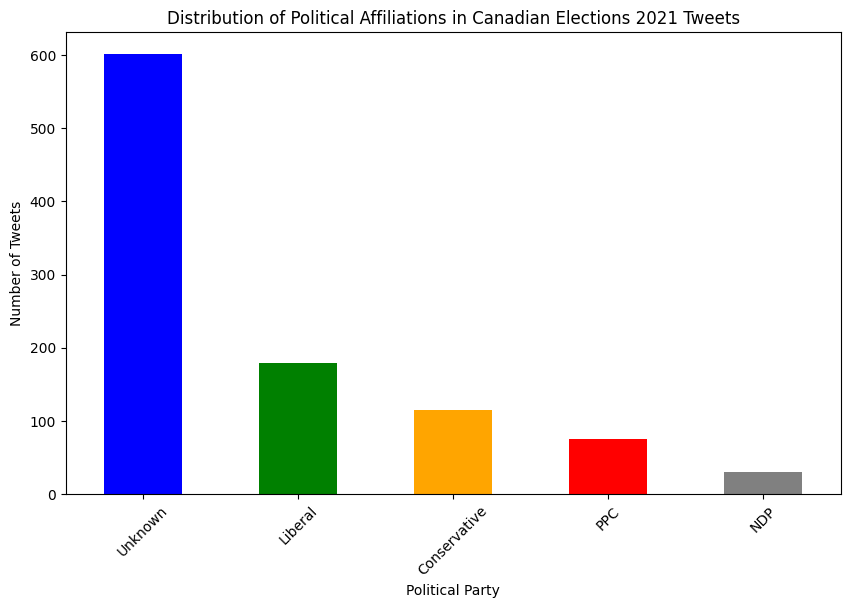

```python
party_counts = df_ce['Party'].value_counts()

plt.figure(figsize=(10, 6))
party_counts.plot(kind='bar', color=['blue', 'green', 'orange', 'red', 'gray'])
plt.title('Distribution of Political Affiliations in Canadian Elections 2021 Tweets')
plt.xlabel('Political Party')
plt.ylabel('Number of Tweets')
plt.xticks(rotation=45)
plt.show()
```

When looking at the distribution, the most high distribution is those whose affiliation is not clearly known, and the second most common is liberal. In that order, conservative, PPC, and NDP follow.

```
Word Cloud for Unknown Tweets
```

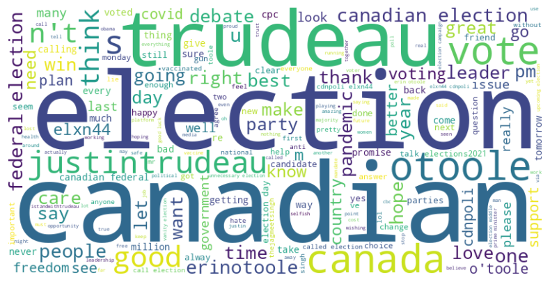

```
Word Cloud for NDP Tweets
```

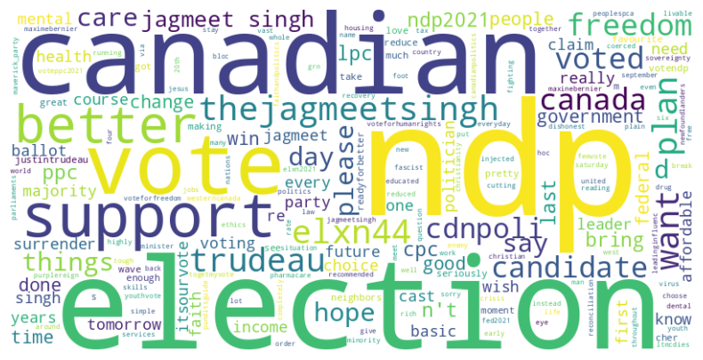

```
Word Cloud for PPC Tweets
```

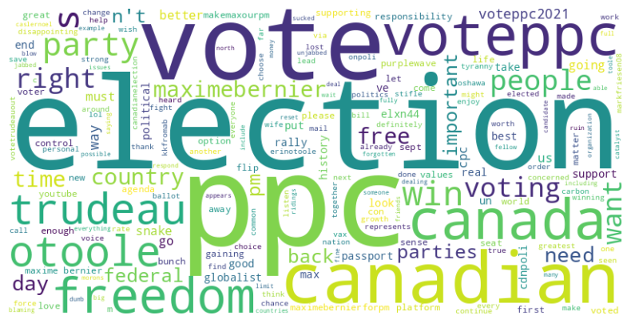

```
Word Cloud for Liberal Tweets
```

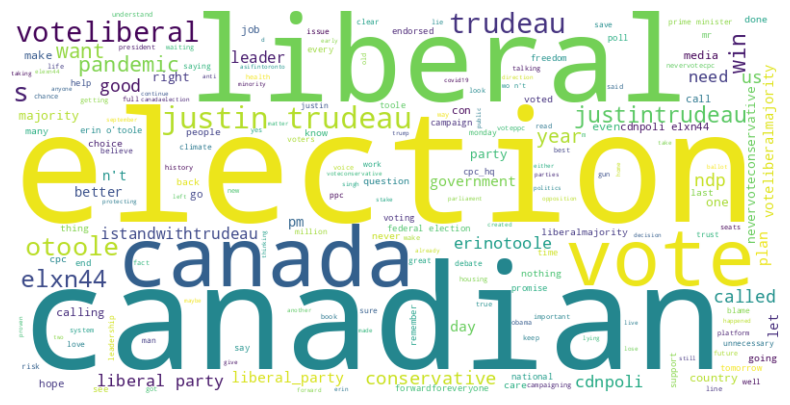

```
Word Cloud for Conservative Tweets
```

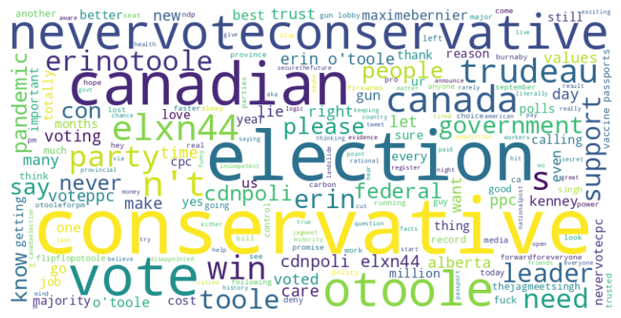

```python
# word cloud
def generate_word_cloud(text):
  wordcloud = WordCloud(width=800, height=400, background_color='white').generate(" ".join(text))
  plt.figure(figsize=(10, 5))
  plt.imshow(wordcloud, interpolation='bilinear')
  plt.axis('off')
  plt.show()


for party in df_ce['Party'].unique():
  print(f"Word Cloud for {party} Tweets")
  party_tweets = df_ce[df_ce['Party'] == party]['text']
  generate_word_cloud(party_tweets)
```

```
Sentiment Distribution for Canadian Elections Tweets
```

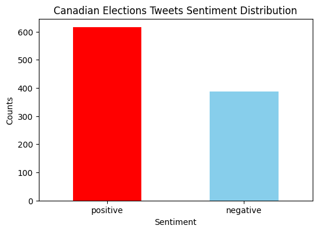

```python
def plot_sentiment_distribution(df, title):
  sentiment_counts = df['sentiment'].value_counts()
  colors = ['red' if sentiment == 'positive' else 'skyblue' for sentiment in sentiment_counts.index]

  plt.figure(figsize=(6, 4))
  sentiment_counts.plot(kind='bar', color=colors)
  plt.title(title)
  plt.xlabel('Sentiment')
  plt.ylabel('Counts')
  plt.xticks(rotation=0)
  plt.show()

print("Sentiment Distribution for Canadian Elections Tweets")
plot_sentiment_distribution(df_ce, "Canadian Elections Tweets Sentiment Distribution")
```

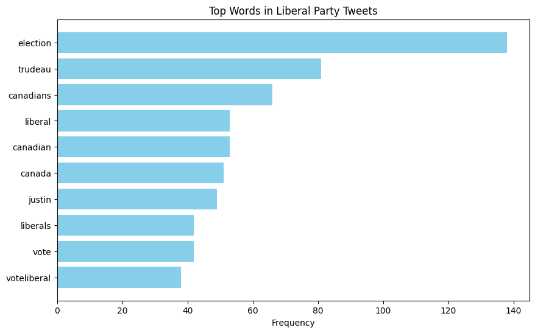

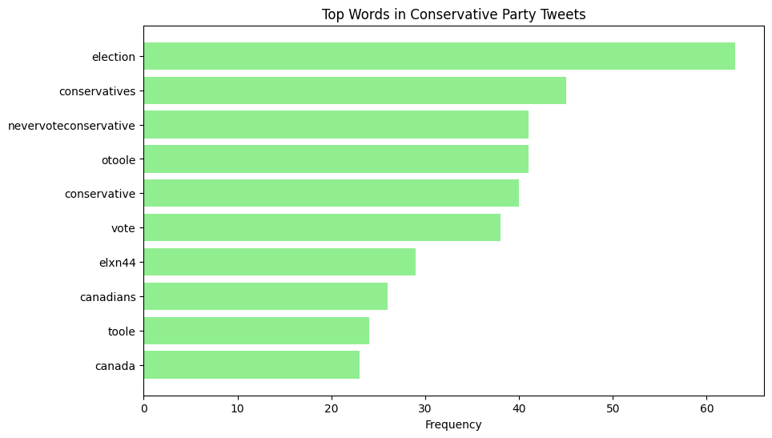

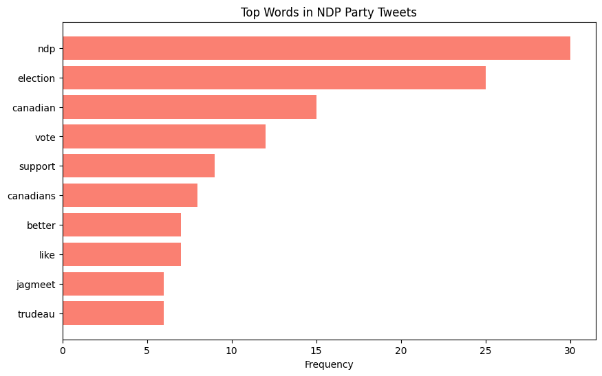

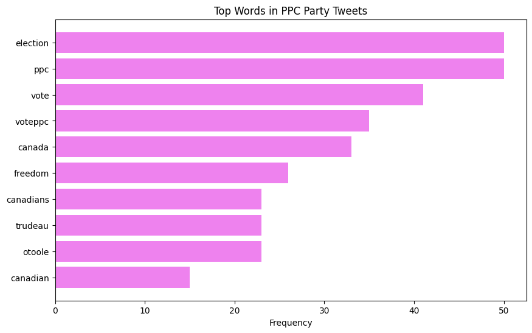

```python
def display_top_words(text, n=10):
  vectorizer = CountVectorizer(stop_words='english', max_features=n)
  word_matrix = vectorizer.fit_transform(text)
  sum_words = word_matrix.sum(axis=0)
  words_freq = [(word, sum_words[0, idx]) for word, idx in vectorizer.vocabulary_.items()]
  words_freq = sorted(words_freq, key=lambda x: x[1], reverse=True)
  df_words = pd.DataFrame(words_freq, columns=['Word', 'Frequency'])
  return df_words

parties = ['Liberal', 'Conservative', 'NDP', 'PPC']
colors = ['skyblue', 'lightgreen', 'salmon', 'violet']

for party, color in zip(parties, colors):
  party_tweets = df_ce[df_ce['Party'] == party]['text']
  df_words_party = display_top_words(party_tweets, n=10)


  plt.figure(figsize=(10, 6))
  plt.barh(df_words_party['Word'], df_words_party['Frequency'], color=color)
  plt.xlabel('Frequency')
  plt.title(f'Top Words in {party} Party Tweets')
  plt.gca().invert_yaxis()
  plt.show()
```

# **3. Model preparation (15 marks)**

Split the generic tweets randomly into training data (80%) and test data 20%).  
Prepare the data to try seven classification algorithms – logistic regression, k-NN, Naive Bayes, SVM, decision trees, Random Forest and XGBoost, where each tweet is considered a single observation/example. In these models, the target variable is the sentiment value, which is either positive or negative. Try four different types of features, Bag of Words (word frequency), TF-IDF, word embedding, and N-grams on all 7 models. (Hint: Be careful about when to split the dataset into training and testing sets.)

```python
# import package related to Model Preparation
from sklearn.decomposition import TruncatedSVD
from sklearn.model_selection import train_test_split
from sklearn.feature_extraction.text import TfidfVectorizer,CountVectorizer
```

```python
from sklearn.preprocessing import LabelEncoder
from gensim.models import Word2Vec
```

```python
X_train, X_test, y_train, y_test = train_test_split(df_sa['text'], df_sa['label'], test_size=0.2, random_state=42)
```

```python
print(X_train.shape)
```

```
(440312,)
```

```python
# Bag of Words
count_vectorizer = CountVectorizer()
X_train_bow = count_vectorizer.fit_transform(X_train)
X_test_bow = count_vectorizer.transform(X_test)
```

```python
# TF-IDF
tfidf_vectorizer = TfidfVectorizer()
X_train_tfidf = tfidf_vectorizer.fit_transform(X_train)
X_test_tfidf = tfidf_vectorizer.transform(X_test)
```

```python
def document_vector(word2vec_model, doc):
  doc = [word for word in doc if word in word2vec_model.wv.key_to_index]
  if not doc:
    return np.zeros(word2vec_model.vector_size)
  return np.mean(word2vec_model.wv[doc], axis=0)

word2vec_model = Word2Vec(sentences=X_train, vector_size=100, window=5, min_count=1, workers=4)
X_train_vectors = np.array([document_vector(word2vec_model, doc) for doc in X_train])
X_test_vectors = np.array([document_vector(word2vec_model, doc) for doc in X_test])
```

```
WARNING:gensim.models.word2vec:Each 'sentences' item should be a list of words (usually unicode strings). First item here is instead plain <class 'str'>.
```

```python
# N-grams
ngram_vectorizer = CountVectorizer(ngram_range=(1, 2))
X_train_ngrams = ngram_vectorizer.fit_transform(X_train)
X_test_ngrams = ngram_vectorizer.transform(X_test)
```

```python
# Convert sentiment labels into numerical values
label_encoder = LabelEncoder()
y_train_encoded = label_encoder.fit_transform(y_train)
y_test_encoded = label_encoder.transform(y_test)
```

# **4. Model implementation and tuning (60 marks)**

**4.1)** Using four types of features (Bag of Words and TF-IDF, word embeddings, and N-grams), train models on the training data from generic tweets and apply the model to the test data to obtain an accuracy value.

**a.** Evaluate the trained model with the best performance on the Canadian Elections data. How well do your predictions match the sentiment labelled in the Canadian elections data?

```python
import time

# import modelization related packages
from sklearn.linear_model import LogisticRegression
from sklearn.neighbors import KNeighborsClassifier
from sklearn.naive_bayes import GaussianNB, MultinomialNB
from sklearn.svm import LinearSVC
from sklearn.tree import DecisionTreeClassifier
from sklearn.ensemble import RandomForestClassifier
from xgboost import XGBClassifier
from sklearn.metrics import accuracy_score, f1_score

from sklearn.model_selection import GridSearchCV
```

```python
models = {
    'Logistic Regression': LogisticRegression(max_iter=1000),
    'SVM': LinearSVC(),
    'K-NN': KNeighborsClassifier(),
    'Naive Bayes': MultinomialNB(),
    'Decision Trees': DecisionTreeClassifier(),
    'Random Forest': RandomForestClassifier(),
    'XGBoost': XGBClassifier(use_label_encoder=False, eval_metric='logloss')
}

features = {
    'Bag of Words': (X_train_bow, X_test_bow),
    'TF-IDF': (X_train_tfidf, X_test_tfidf),
    'Word Embeddings': (X_train_vectors, X_test_vectors),
    'N-grams': (X_train_ngrams, X_test_ngrams)
}
```

```python
from sklearn.metrics import accuracy_score, classification_report
import pickle

def evaluate_model(model, X_train, X_test, y_train, y_test):
    model.fit(X_train, y_train)
    y_pred = model.predict(X_test)
    accuracy = accuracy_score(y_test, y_pred)
    report = classification_report(y_test, y_pred)
    return model, accuracy, report

best_accuracy = 0
for model_name, model in models.items():
    for feature_name, (X_train_feature, X_test_feature) in features.items():
        if model_name == 'Naive Bayes' and feature_name == 'Word Embeddings':
            continue

        trained_model, accuracy, report = evaluate_model(model, X_train_feature, X_test_feature, y_train_encoded, y_test_encoded)
        print(f'Accuracy: {accuracy}, Model Name: {model_name}, Feature Name: {feature_name}')

        if accuracy > best_accuracy:
            best_accuracy = accuracy
            best_model = (model_name, feature_name, trained_model)
            best_report = report

        filename = f'{model_name}_{feature_name}.pkl'
        with open(filename, 'wb') as f:
            pickle.dump(trained_model, f)
        print(f'Model saved as {filename}')

if best_model:
    print("Best Model:", best_model[0], "with", best_model[1], "feature")
    print("Accuracy:", best_accuracy)
    print("Classification Report:")
    print(best_report)

    best_filename = f'best_model_{best_model[0]}_{best_model[1]}.pkl'
    with open(best_filename, 'wb') as f:
        pickle.dump(best_model[2], f)
    print(f'Best model saved as {best_filename}')
```

```
Accuracy: 0.9698855377906976, Model Name: Logistic Regression, Feature Name: Bag of Words
Model saved as Logistic Regression_Bag of Words.pkl
Accuracy: 0.9641170058139535, Model Name: Logistic Regression, Feature Name: TF-IDF
Model saved as Logistic Regression_TF-IDF.pkl
Accuracy: 0.7436864098837209, Model Name: Logistic Regression, Feature Name: Word Embeddings
Model saved as Logistic Regression_Word Embeddings.pkl
Accuracy: 0.9692950581395349, Model Name: Logistic Regression, Feature Name: N-grams
Model saved as Logistic Regression_N-grams.pkl
Accuracy: 0.9720203488372093, Model Name: SVM, Feature Name: Bag of Words
Model saved as SVM_Bag of Words.pkl
Accuracy: 0.9735646802325582, Model Name: SVM, Feature Name: TF-IDF
Model saved as SVM_TF-IDF.pkl
Accuracy: 0.7438226744186046, Model Name: SVM, Feature Name: Word Embeddings
Model saved as SVM_Word Embeddings.pkl
Accuracy: 0.9712936046511628, Model Name: SVM, Feature Name: N-grams
Model saved as SVM_N-grams.pkl
Accuracy: 0.8489280523255814, Model Name: K-NN, Feature Name: Bag of Words
Model saved as K-NN_Bag of Words.pkl
Accuracy: 0.861328125, Model Name: K-NN, Feature Name: TF-IDF
Model saved as K-NN_TF-IDF.pkl
Accuracy: 0.7110737645348837, Model Name: K-NN, Feature Name: Word Embeddings
Model saved as K-NN_Word Embeddings.pkl
Accuracy: 0.770984738372093, Model Name: K-NN, Feature Name: N-grams
Model saved as K-NN_N-grams.pkl
Accuracy: 0.9423146802325582, Model Name: Naive Bayes, Feature Name: Bag of Words
Model saved as Naive Bayes_Bag of Words.pkl
Accuracy: 0.8523800872093024, Model Name: Naive Bayes, Feature Name: TF-IDF
Model saved as Naive Bayes_TF-IDF.pkl
Accuracy: 0.9356377180232558, Model Name: Naive Bayes, Feature Name: N-grams
Model saved as Naive Bayes_N-grams.pkl
Accuracy: 0.9322765261627907, Model Name: Decision Trees, Feature Name: Bag of Words
Model saved as Decision Trees_Bag of Words.pkl
Accuracy: 0.9164244186046512, Model Name: Decision Trees, Feature Name: TF-IDF
Model saved as Decision Trees_TF-IDF.pkl
Accuracy: 0.6595203488372093, Model Name: Decision Trees, Feature Name: Word Embeddings
Model saved as Decision Trees_Word Embeddings.pkl
Accuracy: 0.9317768895348837, Model Name: Decision Trees, Feature Name: N-grams
Model saved as Decision Trees_N-grams.pkl
Accuracy: 0.9421329941860465, Model Name: Random Forest, Feature Name: Bag of Words
Model saved as Random Forest_Bag of Words.pkl
```

[output cut: 12 more lines]

```
Accuracy: 0.9301417151162791, Model Name: XGBoost, Feature Name: N-grams
Model saved as XGBoost_N-grams.pkl
Best Model: SVM with TF-IDF feature
Accuracy: 0.9735646802325582
Classification Report:
              precision    recall  f1-score   support

           0       0.96      0.96      0.96      7052
           1       0.98      0.98      0.98     14964

    accuracy                           0.97     22016
   macro avg       0.97      0.97      0.97     22016
weighted avg       0.97      0.97      0.97     22016

Best model saved as best_model_SVM_TF-IDF.pkl
```

```python
le = LabelEncoder()
df_ce['encoded_sentiment'] = le.fit_transform(df_ce['sentiment'])
X_ce_tfidf = tfidf_vectorizer.transform(df_ce['text'])


filename = 'SVM_TF-IDF.pkl'
with open(filename, 'rb') as f:
    best_model = pickle.load(f)

y_ce_pred = best_model.predict(X_ce_tfidf)

accuracy_ce = accuracy_score(df_ce['encoded_sentiment'], y_ce_pred)
report_ce = classification_report(df_ce['encoded_sentiment'], y_ce_pred)

print("Accuracy on Canadian Elections Data:", accuracy_ce)
print("Classification Report on Canadian Elections Data:")
print(report_ce)
```

```
Accuracy on Canadian Elections Data: 0.6726546906187625
Classification Report on Canadian Elections Data:
              precision    recall  f1-score   support

           0       0.54      0.93      0.69       387
           1       0.92      0.51      0.66       615

    accuracy                           0.67      1002
   macro avg       0.73      0.72      0.67      1002
weighted avg       0.77      0.67      0.67      1002
```

**b.** Propose three other metrics you could use to evaluate the models. Then evaluate the models accordingly. In one to two sentences, provide reasoning for each metric.

```python
import pandas as pd
import pickle
from sklearn.metrics import precision_score, recall_score, f1_score

model_names = list(models.keys())
feature_names = list(features.keys())

evaluation_results = []

for model_name, model in models.items():
    for feature_name, (X_train_feature, X_test_feature) in features.items():
        if model_name == 'Naive Bayes' and feature_name == 'Word Embeddings':
            continue

        model_filename = f"{model_name}_{feature_name}.pkl"
        with open(model_filename, "rb") as f:
            trained_model = pickle.load(f)

        y_pred = trained_model.predict(X_test_feature)

        precision = precision_score(y_test_encoded, y_pred, average='binary')
        recall = recall_score(y_test_encoded, y_pred, average='binary')
        f1 = f1_score(y_test_encoded, y_pred, average='binary')

        print(f"Metrics for {model_name} with {feature_name} features:")
        print(f"Precision: {precision:.4f}")
        print(f"Recall: {recall:.4f}")
        print(f"F1 Score: {f1:.4f}\n")

        evaluation_results.append({
            "Model": model_name,
            "Feature": feature_name,
            "Precision": precision,
            "Recall": recall,
            "F1 Score": f1
        })

df_evaluation_results = pd.DataFrame(evaluation_results)
df_evaluation_results.to_csv("model_evaluation_results.csv", index=False)

print(df_evaluation_results)
```

```
Metrics for Logistic Regression with Bag of Words features:
Precision: 0.9793
Recall: 0.9763
F1 Score: 0.9778

Metrics for Logistic Regression with TF-IDF features:
Precision: 0.9702
Recall: 0.9772
F1 Score: 0.9737

Metrics for Logistic Regression with Word Embeddings features:
Precision: 0.6899
Recall: 0.8865
F1 Score: 0.7759

Metrics for Logistic Regression with N-grams features:
Precision: 0.9795
Recall: 0.9753
F1 Score: 0.9774

Metrics for SVM with Bag of Words features:
Precision: 0.9808
Recall: 0.9779
F1 Score: 0.9794

Metrics for SVM with TF-IDF features:
Precision: 0.9798
Recall: 0.9813
F1 Score: 0.9806

Metrics for SVM with Word Embeddings features:
Precision: 0.6819
Recall: 0.9382
F1 Score: 0.7898

Metrics for SVM with N-grams features:
Precision: 0.9811
Recall: 0.9766
F1 Score: 0.9788

```

[output cut: 108 more lines]

```
12          Naive Bayes     Bag of Words   0.933519  0.985298  0.958710
13          Naive Bayes           TF-IDF   0.822913  0.997461  0.901819
14          Naive Bayes          N-grams   0.924059  0.986367  0.954197
15       Decision Trees     Bag of Words   0.950813  0.949479  0.950145
16       Decision Trees           TF-IDF   0.936826  0.940457  0.938638
17       Decision Trees  Word Embeddings   0.635154  0.178696  0.278919
18       Decision Trees          N-grams   0.949392  0.950281  0.949836
19        Random Forest     Bag of Words   0.942012  0.974873  0.958161
20        Random Forest           TF-IDF   0.927550  0.975341  0.950845
21        Random Forest  Word Embeddings   0.642105  0.203823  0.309425
22        Random Forest          N-grams   0.926837  0.976945  0.951231
23              XGBoost     Bag of Words   0.967906  0.927092  0.947059
24              XGBoost           TF-IDF   0.966098  0.923617  0.944380
25              XGBoost  Word Embeddings   0.675637  0.686247  0.680900
26              XGBoost          N-grams   0.968327  0.927559  0.947505
```

When evaluating performance solely based on accuracy, it might overlook specific aspects that Precision, Recall, and F1 Score capture effectively.

1. Precision:
   - Precision focuses on minimizing False Positives. Therefore, considering Precision is beneficial when aiming to reduce the instances where the model incorrectly predicts positive cases. For instance, in spam email filtering, prioritizing Precision can decrease the number of emails falsely classified as spam for users.
2. Recall (Sensitivity):
   - Recall prioritizes minimizing False Negatives. By considering Recall, one can minimize the risk of missing actual positive cases. In medical diagnosis, considering Recall can reduce the risk of overlooking diseases.
3. F1 Score:
   - F1 Score provides a balance between Precision and Recall. As there might be a trade-off between Precision and Recall at times, it's crucial to consider both. F1 Score evaluates this balance, offering a holistic view of the model's performance. It helps in suggesting more effective directions for improving the model's performance.

**c.** Choose the model that has the best performance and visualize the sentiment prediction results and the true sentiment for each of the 4 parties. From this model, discuss your findings and whether NLP analytics based on tweets is useful for political parties during election campaigns. Explain how each party is viewed in the public eye based on the sentiment value. Suggest one way you can improve the accuracy of this model.

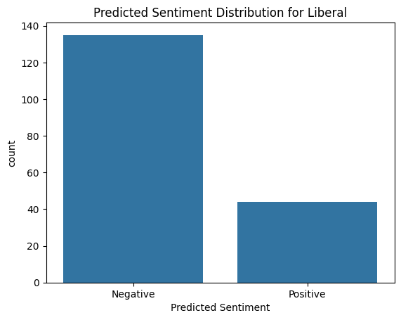

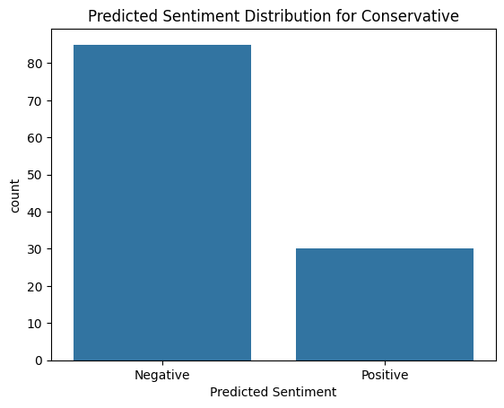

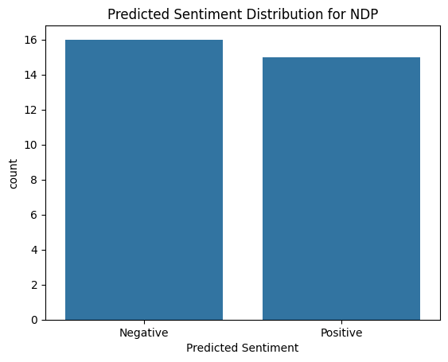

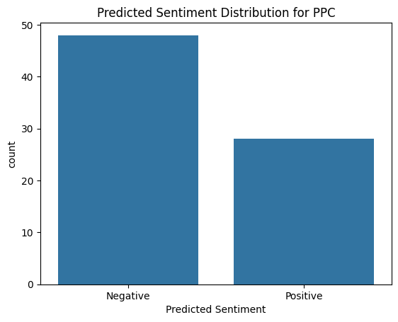

```python
with open('SVM_TF-IDF.pkl', 'rb') as f:
  best_model = pickle.load(f)

y_pred_sa = best_model.predict(X_ce_tfidf)

df_ce['Predicted Sentiment'] = y_pred_sa

sentiment_map = {0: 'Negative', 1: 'Positive'}
df_ce['Predicted Sentiment'] = df_ce['Predicted Sentiment'].map(sentiment_map)

for party in ['Liberal', 'Conservative', 'NDP', 'PPC']:
    df_party = df_ce[df_ce['Party'] == party]
    sns.countplot(x='Predicted Sentiment', data=df_party, order=['Negative', 'Positive'])
    plt.title(f"Predicted Sentiment Distribution for {party}")
    plt.show()
```

**4.2)** Split the negative Canadian elections tweets into training data (80%) and test data (20%). Use the true sentiment labels in the Canadian elections data instead of your predictions from the previous part. Choose one algorithms from classification algorithms (choose any model from logistic regression, k-NN, Naive Bayes, SVM, decision trees, RF, XGBoost), train multi-class classification model to predict the reason for the negative tweets. Tune the hyperparameters and chose the model with best score to test your prediction reason for negative sentiment tweets.

```python
df_ce[df_ce['sentiment'] == 'negative']
```

|  | text | sentiment | negative_reason | Party | encoded_sentiment | Predicted Sentiment |
| --- | --- | --- | --- | --- | --- | --- |
| 0 | canadian election power grab pm trudeau , yes ... | negative | calling election early | Unknown | 0 | Positive |
| 1 | hope trudeau loses canadian election tomorrow ... | negative | covid | Unknown | 0 | Negative |
| 3 | canadian friends : never forget trudeau 2 year... | negative | calling election early | Unknown | 0 | Negative |
| 5 | vaccines & guns key election o'toole serious p... | negative | covid | Unknown | 0 | Negative |
| 6 | ’ sorry , moderators respond leadership candid... | negative | others | Unknown | 0 | Negative |
| ... | ... | ... | ... | ... | ... | ... |
| 997 | absolutely horrible canada . forthcoming elect... | negative | others | Unknown | 0 | Negative |
| 998 | @ davidakin trudeau imposes gun control polici... | negative | gun control | Unknown | 0 | Negative |
| 999 | canada 🇨🇦 election stolen thugs . uneducated g... | negative | others | Unknown | 0 | Negative |
| 1000 | o'toole amends platform gun control , question... | negative | tell lies | Unknown | 0 | Negative |
| 1001 | @ justintrudeau stop lies , stop manipulation ... | negative | tell lies | Unknown | 0 | Negative |

387 rows × 6 columns

```python
df_ce[df_ce['sentiment'] == 'positive']
```

|  | text | sentiment | negative_reason | Party | encoded_sentiment | Predicted Sentiment |
| --- | --- | --- | --- | --- | --- | --- |
| 2 | dear canadians , election test progressive . w... | positive | NaN | Unknown | 1 | Negative |
| 4 | sorry @ thejagmeetsingh voted # ndp life elect... | positive | NaN | NDP | 1 | Negative |
| 8 | canadians # voteppc support @ maximebernier wo... | positive | NaN | PPC | 1 | Positive |
| 9 | justin trudeau literally rocks thrown yet cont... | positive | NaN | Liberal | 1 | Negative |
| 12 | # throwbackthursday federal election debate ni... | positive | NaN | Unknown | 1 | Negative |
| ... | ... | ... | ... | ... | ... | ... |
| 938 | election canadian freedom ! ! ! without freedo... | positive | NaN | Unknown | 1 | Negative |
| 940 | progressive conservative government unfortunat... | positive | NaN | Liberal | 1 | Negative |
| 943 | last one night ! lookin like us ndp need rally... | positive | NaN | Conservative | 1 | Negative |
| 969 | # justintrudeau killing ! 'd hate # otoole rig... | positive | NaN | Liberal | 1 | Negative |
| 984 | @ justintrudeau justin , rifles ’ hurt people ... | positive | NaN | Unknown | 1 | Negative |

615 rows × 6 columns

```python
negative_tweets = df_ce[df_ce['sentiment'] == 'negative'][['text', 'negative_reason']]

X_neg = negative_tweets['text']
y_neg = negative_tweets['negative_reason']
X_train_neg, X_test_neg, y_train_neg, y_test_neg = train_test_split(X_neg, y_neg, test_size=0.2, random_state=42)

tfidf_vectorizer_neg = TfidfVectorizer(stop_words='english', max_features=1000)
X_train_neg_tfidf = tfidf_vectorizer_neg.fit_transform(X_train_neg)
X_test_neg_tfidf = tfidf_vectorizer_neg.transform(X_test_neg)

svm_clf = LinearSVC(random_state=42)

param_grid = {
    'C': [0.01, 0.1, 1, 10]
}

grid_search = GridSearchCV(estimator=svm_clf, param_grid=param_grid, cv=3, scoring='accuracy', verbose=2, n_jobs=-1)
grid_search.fit(X_train_neg_tfidf, y_train_neg)

best_hyperparameters = grid_search.best_params_
print("Best Hyperparameters:", best_hyperparameters)

best_svm_clf = grid_search.best_estimator_

y_pred_neg = best_svm_clf.predict(X_test_neg_tfidf)
accuracy_neg = accuracy_score(y_test_neg, y_pred_neg)
print("Accuracy on Negative Sentiment Reason Prediction:", accuracy_neg)
print("Classification Report:")
print(classification_report(y_test_neg, y_pred_neg))
```

```
Fitting 3 folds for each of 4 candidates, totalling 12 fits
```

```
Best Hyperparameters: {'C': 1}
Accuracy on Negative Sentiment Reason Prediction: 0.48717948717948717
Classification Report:
                                     precision    recall  f1-score   support

             calling election early       0.60      0.64      0.62        14
                    climate problem       0.33      0.50      0.40         2
                             covid        0.00      0.00      0.00         8
                            economy       1.00      0.60      0.75         5
                        gun control       0.50      0.50      0.50         2
           healthcare and marijuana       0.00      0.00      0.00         3
                             others       0.51      0.77      0.61        30
                            scandal       0.00      0.00      0.00         1
                          tell lies       0.14      0.09      0.11        11
women reproductive right and racism       0.00      0.00      0.00         2

                           accuracy                           0.49        78
                          macro avg       0.31      0.31      0.30        78
                       weighted avg       0.41      0.49      0.43        78
```

```python
y_neg.value_counts()
```

```
others                                 149
calling election early                  73
tell lies                               61
covid                                   25
economy                                 20
gun control                             16
climate problem                         15
scandal                                 14
healthcare and marijuana                 7
women reproductive right and racism      4
segregation                              3
Name: negative_reason, dtype: int64
```

**a. Provide a few reasons why your model may fail to predict the correct negative reasons. Back up your reasoning with examples from the test sets.**

There may be several reasons, but the first reason is the amount of data. Due to the insufficient amount of data in ce, the model may not have learned the data patterns in detail. The second reason is the complexity of the model. Finding negative reasons through words is difficult. This may require a more complex model or a different method of selecting features.

```python
df_ce[df_ce['sentiment'] == 'negative'].shape[0]
```

```
387
```

**b. Suggest one way you can improve the accuracy of your selected model.**

The reason the model's performance is low is also due to the low complexity of the model. To solve this, we propose ensemble, a method of improving the final prediction by combining predictions from several different models.

```python
df_ce.head()
```

|  | text | sentiment | negative_reason | Party | encoded_sentiment | Predicted Sentiment |
| --- | --- | --- | --- | --- | --- | --- |
| 0 | canadian election power grab pm trudeau , yes ... | negative | calling election early | Unknown | 0 | Positive |
| 1 | hope trudeau loses canadian election tomorrow ... | negative | covid | Unknown | 0 | Negative |
| 2 | dear canadians , election test progressive . w... | positive | NaN | Unknown | 1 | Negative |
| 3 | canadian friends : never forget trudeau 2 year... | negative | calling election early | Unknown | 0 | Negative |
| 4 | sorry @ thejagmeetsingh voted # ndp life elect... | positive | NaN | NDP | 1 | Negative |

```python
base_models = [
    ('rf_clf', RandomForestClassifier(n_estimators=100, random_state=42)),
    ('svc', SVC(probability=True, kernel='linear', C=1)),
    ('gb_clf', GradientBoostingClassifier(n_estimators=100, random_state=42))
]

meta_model = LogisticRegression()

stacking_clf = StackingClassifier(estimators=base_models, final_estimator=meta_model, cv=5)

tfidf_vectorizer = TfidfVectorizer(stop_words='english', max_features=1000)
X = tfidf_vectorizer.fit_transform(df_ce['text'])
y = df_ce['encoded_sentiment']

X_train, X_test, y_train, y_test = train_test_split(X, y, test_size=0.2, random_state=42)
stacking_clf.fit(X_train, y_train)

y_pred = stacking_clf.predict(X_test)
accuracy = accuracy_score(y_test, y_pred)
print(f'Accuracy: {accuracy}')
```

```
Accuracy: 0.7960199004975125
```

**c. Combine similar reasons into fewer categories, as long as you justify your reasoning. You are free to define input features of your model using word frequency analysis or other techniques.**

```python
# your code start from here.
def reclassify_reasons(row):
  if row in ['healthcare and marijuana', 'women reproductive right and racism', 'segregation']:
      return 'social issues'
  elif row in ['calling election early', 'tell lies']:
      return 'political strategy/integrity'
  elif row in ['covid', 'economy', 'gun control', 'climate problem', 'scandal']:
      return row
  else:
      return 'others'


df_ce['negative_reason_reclassified'] = df_ce['negative_reason'].apply(reclassify_reasons)
negative_tweets = df_ce[df_ce['sentiment'] == 'negative'][['text', 'negative_reason']]


X_neg = negative_tweets['text']
y_neg = negative_tweets['negative_reason']
X_train_neg, X_test_neg, y_train_neg, y_test_neg = train_test_split(X_neg, y_neg, test_size=0.2, random_state=42)

tfidf_vectorizer_neg = TfidfVectorizer(stop_words='english', max_features=1000)
X_train_neg_tfidf = tfidf_vectorizer_neg.fit_transform(X_train_neg)
X_test_neg_tfidf = tfidf_vectorizer_neg.transform(X_test_neg)

base_models = [
    ('rf_clf', RandomForestClassifier(n_estimators=100, random_state=42)),
    ('svc', SVC(probability=True, kernel='linear', C=1)),
    ('gb_clf', GradientBoostingClassifier(n_estimators=100, random_state=42))
]

meta_model = LogisticRegression()

stacking_clf = StackingClassifier(estimators=base_models, final_estimator=meta_model, cv=5)

tfidf_vectorizer = TfidfVectorizer(stop_words='english', max_features=1000)
X = tfidf_vectorizer.fit_transform(df_ce['text'])
y = df_ce['encoded_sentiment']

X_train, X_test, y_train, y_test = train_test_split(X, y, test_size=0.2, random_state=42)
stacking_clf.fit(X_train, y_train)

y_pred = stacking_clf.predict(X_test)
accuracy = accuracy_score(y_test, y_pred)
print(f'Accuracy: {accuracy}')
```

```
Accuracy: 0.8009950248756219
```

```python
#!pip install nbconvert
%%shell
jupyter nbconvert --to html
```

[output not shown]